# Midterm 2 - Report

Nicholas Lai

November 17, 2018

## (A) Exploratory Data Analysis

This report deals with the analysis of the data in `data3.csv`. The raw data is shown below:

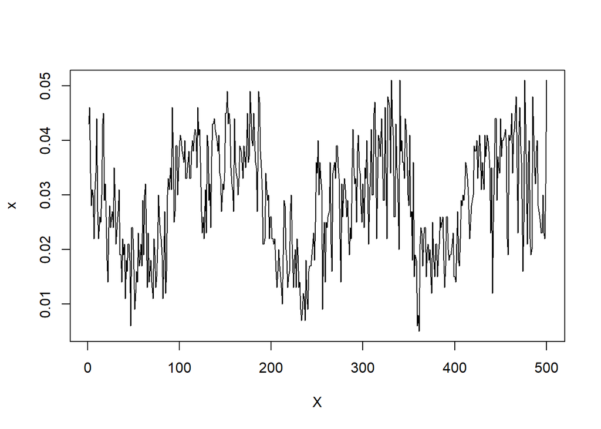

From the data, we see evidence of a seasonal trend and a non-zero mean. In order to analyze this data, we must deal with these issues.

To verify if our data is strongly seasonal, we can look at the `acf` of our data in order to see the correlation structure in our data.

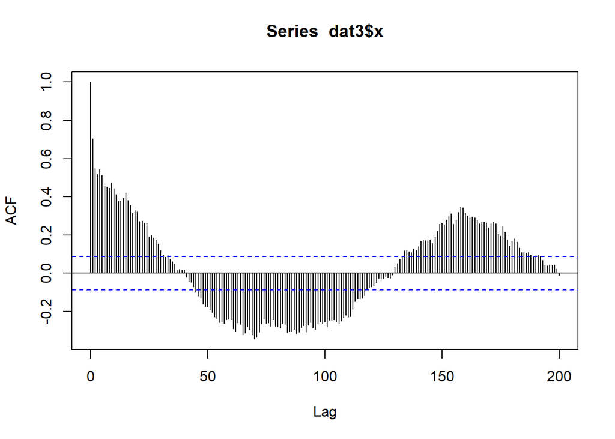

We clearly see a pattern in our `acf` for the raw time series, consistent with seasonality. A natural period to choose for seasonal differencing is the (positive) peak of the acf.

The peak of the ACF corresponds to lag 159. Seasonal differencing with this parameter will eliminate the mean of the data.

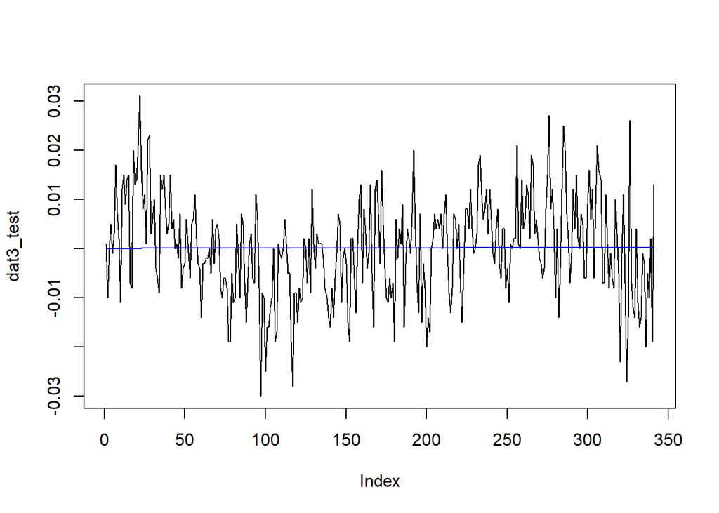

After one seasonal differencing, we obtained a zero mean process (in blue, the regression of the data is shown to be roughly the x axis). On the surface, this process has lost its strong seasonality.

We can verify this with the `acf` and `pacf` of the seasonally differenced series.

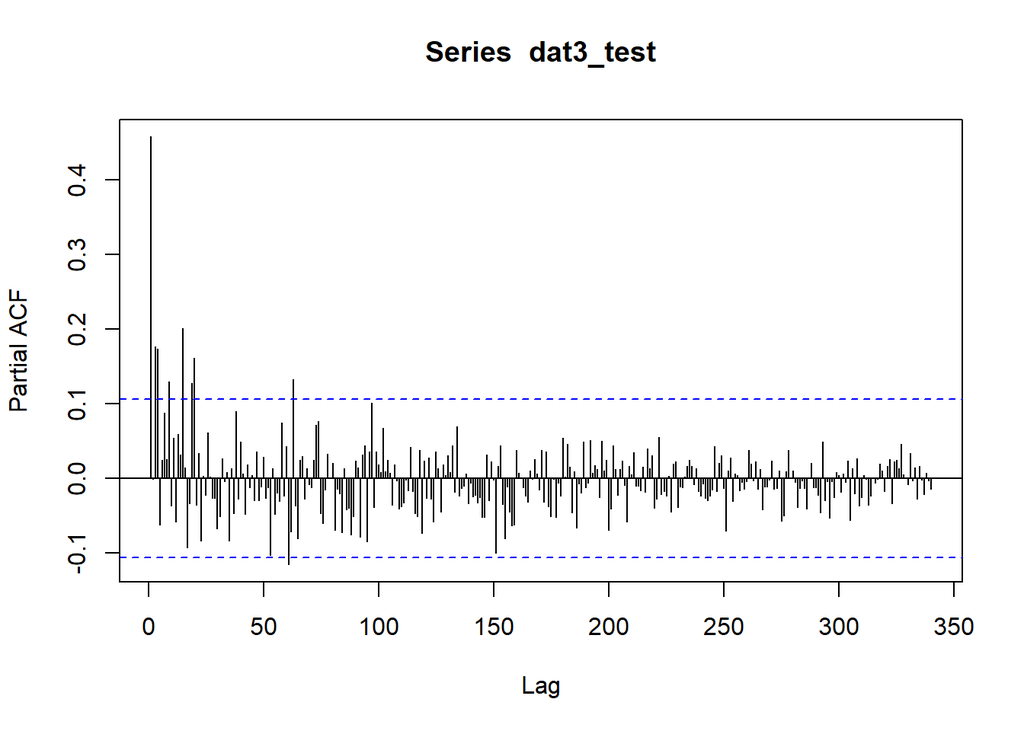

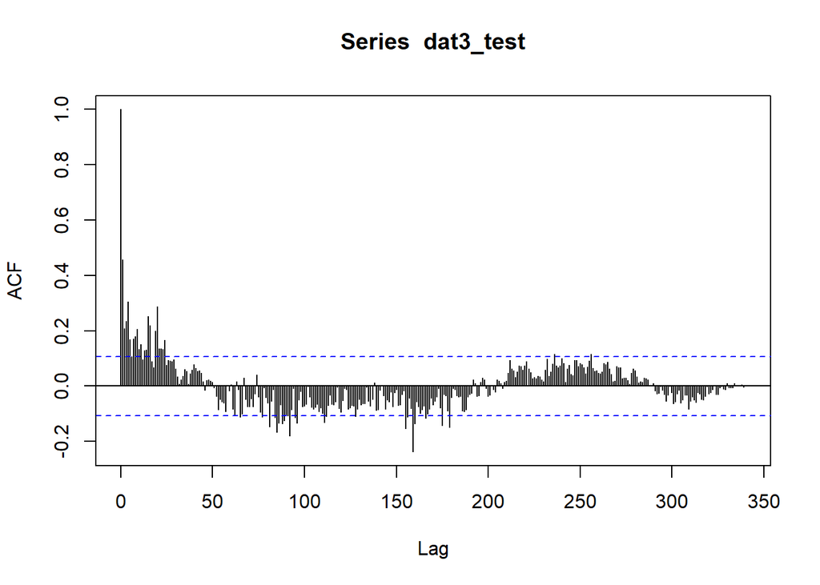

## (B) Identifying suitable ARIMA model

These above plots contain no evidence for any seasonal MA or AR terms, as there are no periodic spikes of particularly large magnitude at any lag beyond the start of the plots. There is some evidence for a AR(2) model, as the lags drop off after 2 and the MA process is exponentially decreasing.

We can verify that a AR(2) model is appropriate by doing criteria-based model selection. From the `acf` and `pacf` plots above, it is unlikely that the optimal MA and AR terms are more than the `auto.arima` defaults, so we can compute the optimal models by AIC and BIC:

```
## Series: dat3$x
## ARIMA(2,0,0) with zero mean
##
## Coefficients:
##          ar1     ar2
##       0.7593  0.2188
## s.e.  0.0438  0.0440
##
## sigma^2 estimated as 5.566e-05:  log likelihood=1739.1
## AIC=-3472.2   AICc=-3472.15   BIC=-3459.55
```

```
## Series: dat3$x
## ARIMA(2,0,0) with zero mean
##
## Coefficients:
##          ar1     ar2
##       0.7593  0.2188
## s.e.  0.0438  0.0440
##
## sigma^2 estimated as 5.566e-05:  log likelihood=1739.1
## AIC=-3472.2   AICc=-3472.15   BIC=-3459.55
```

As expected, the AR(2) model was selected by both AIC and BIC.

We can perform diagnostics on this model:

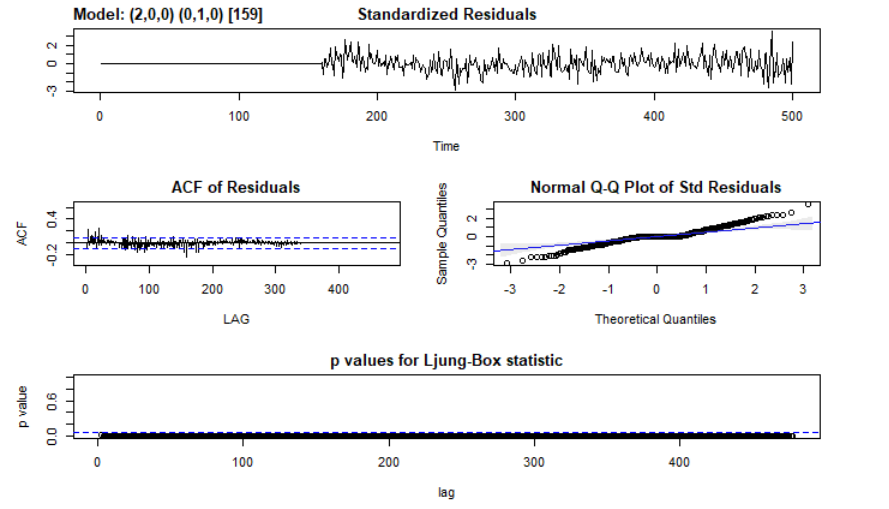

The regression diagnostics show that this model, the most natural one from our seasonal differencing procedure, is not a perfect fit for the data. Our errors, by the Ljung-Box test, are uniformly below the threshold for non-zero autocorrelation for all lags, and our QQplot of the residuals shows long tails, which are evidence of non-normal error. However, there is no discernible pattern in the standardized residuals at a glace.

Other possible SARIMA models arise from alternative differencings. One interesting quirk of our data is that a regular difference of the data yields a seemingly stationary process, despite the data being seemingly seasonal.

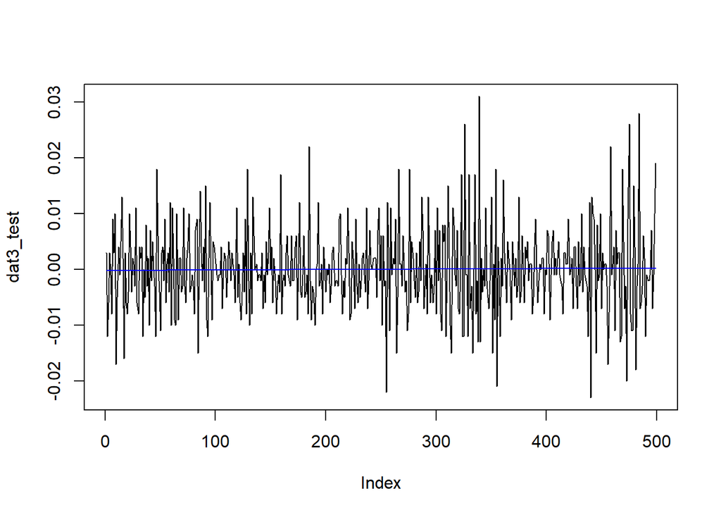

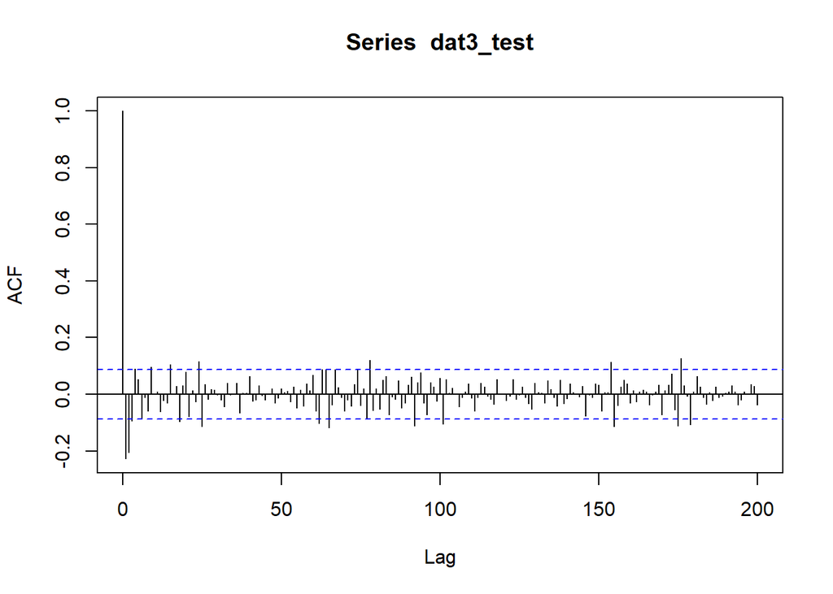

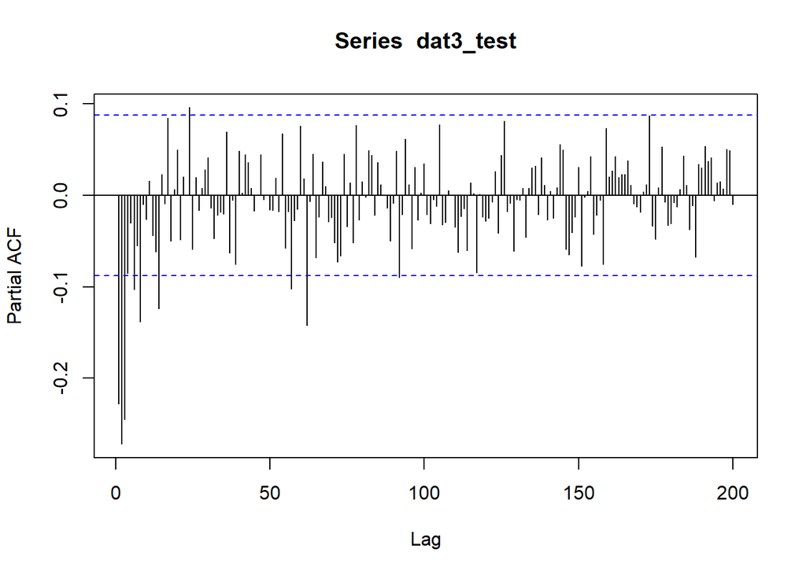

With analagous logic as with the seasonal differencing case, we can select models:

```
## Series: dat3$x
## ARIMA(2,1,5)
##
## Coefficients:
##          ar1      ar2      ma1     ma2      ma3      ma4      ma5
##       0.8975  -0.8741  -1.3378  1.0284  -0.2135  -0.1003  -0.1449
## s.e.  0.0438   0.0458   0.0620  0.0883   0.0902   0.0822   0.0517
##
## sigma^2 estimated as 4.55e-05:  log likelihood=1789.19
## AIC=-3562.38   AICc=-3562.09   BIC=-3528.68
```

```
## Series: dat3$x
## ARIMA(0,1,2)
##
## Coefficients:
##           ma1      ma2
##       -0.4534  -0.2899
## s.e.   0.0414   0.0407
##
## sigma^2 estimated as 4.694e-05:  log likelihood=1779.28
## AIC=-3552.55   AICc=-3552.51   BIC=-3539.92
```

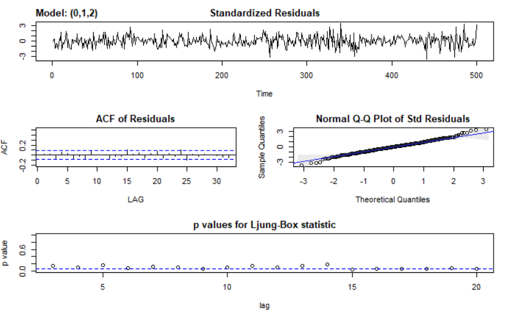

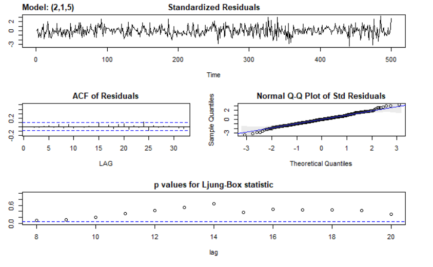

Both of these models, one preferred by BIC and one by AIC, are already huge improvements on the seasonal differencing selected model. Both models have QQplots that show normality of residuals as reasonable, and the Ljung-Box statistics for both models have some points above the threshold for rejection of uncorrelatedness, especially in the case of the ARIMA(2,1,5) model.

Another try at differencing is to take a seasonal difference of the regular difference, if one strongly believes in the seasonality of the data.

```
## Series: dat3$x
## ARIMA(0,1,2)
##
## Coefficients:
##           ma1      ma2
##       -0.4534  -0.2899
## s.e.   0.0414   0.0407
##
## sigma^2 estimated as 4.694e-05:  log likelihood=1779.28
## AIC=-3552.55   AICc=-3552.51   BIC=-3539.92
```

```
## Series: dat3$x
## ARIMA(2,1,5)
##
## Coefficients:
##          ar1      ar2      ma1     ma2      ma3      ma4      ma5
##       0.8975  -0.8741  -1.3378  1.0284  -0.2135  -0.1003  -0.1449
## s.e.  0.0438   0.0458   0.0620  0.0883   0.0902   0.0822   0.0517
##
## sigma^2 estimated as 4.55e-05:  log likelihood=1789.19
## AIC=-3562.38   AICc=-3562.09   BIC=-3528.68
```

The same models are selected as in the regular difference case, but instead with one seasonal difference.

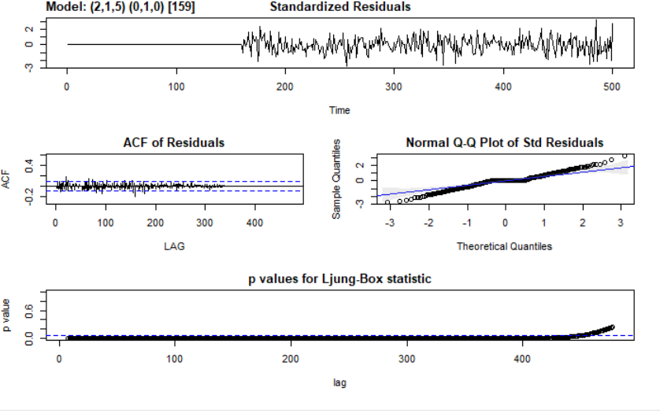

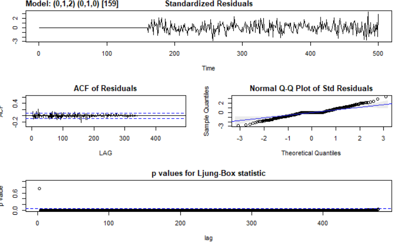

It is clear at this point that seasonal differencing is a lost cause, as the same models as above with seasonal differencing are made worse by every diagnostic.

Now, choosing between our ARIMA(2,1,5) and our ARIMA(0,1,2) models can be done via cross-validation.

```
## [1] 0.01453721
```

```
## [1] 0.01453924
```

The cross-validation score for the ARIMA(2,1,5) model is smaller than the ARIMA(0,1,2) model, so we select the model for our forecast.

# (C) Model Fitting and Forecasting

Forecast:

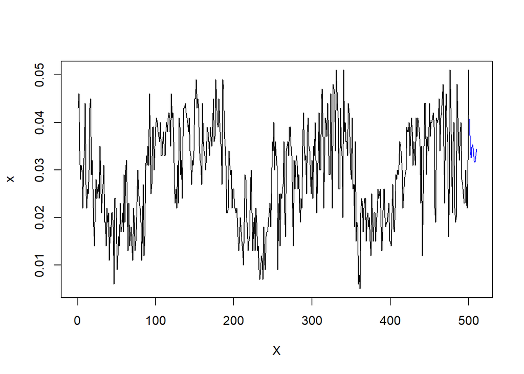

```
## Time Series:
## Start = 501
## End = 510
## Frequency = 1
##  [1] 0.04069609 0.03373826 0.03248971 0.03482059 0.03533187 0.03375332
##  [7] 0.03188969 0.03159689 0.03296311 0.03444521
```